# Lecture 02: Introducing to the Logistic Model

Module on Logistic Regression

# Lecture Goals

- Bridge the discussion of odds to statistical modeling.
- Working from probabilities, to odds, to log-odds.
- Interpreting a Logistic Regression Model.

# A Quick Review of Odds

The Youth Risk Behavior Surveillance System (YRBSS) is a public health initiative by the Center for Disease Control and Prevention (CDC) that monitors six key categories of health-risk behaviors among high school students. The YRBSS is conducted biannually in the spring semester and has been conducted regularly since 1991. We will look at a subset of the survey from 2023.

Specifically, we will look to determine if demographic variables are associated with wether a high school was bullied on school property in the preceding 12 months.

**Sources:** Data: (Centers for Disease Control and Prevention 2024). Concept and Clipart: (Brener et al. 2024).

```r
yrbss <- read_csv("https://tjfisher19.github.io/data/cdc_yrbss_2023.csv",
                  show_col_types=FALSE)
glimpse(yrbss)
```

```
Rows: 17,605
Columns: 6
$ Age               <chr> "14 years old", "16 years old", "14 years old", "16 …
$ Sex               <chr> "Female", "Male", "Male", "Male", "Male", "Female", …
$ Grade             <chr> "9th grade", "11th grade", "9th grade", "9th grade",…
$ Height            <dbl> 1.65, 1.68, 1.85, 1.80, 1.83, 1.52, 1.65, 1.63, 1.70…
$ Weight            <dbl> 81.65, 74.84, 56.70, 72.58, 74.84, 73.48, 61.24, 53.…
$ Bullied_at_School <chr> "No", "No", "No", "No", "No", "No", "No", "No", "No"…
```

The **response variable** of interest is the character variable `Bullied_at_School`, which indicates whether a student has been bullied at school in the past year (“Yes”) or has not (“No”).

There are multiple **predictor variables** available in this data, but in the previous lecture we focused on Height (m) and Grade. We discussed how the variable `Bullied_at_School` can be considered a Binomial random variable, and that the underlying parameter of interest is $p$, the probability (or proportion) a student has been bullied (here, a *success* is a student being bullied, not contextually a success).

We looked to model this probability by converting it into odds:
$$odds~\text{of being bullied} = \frac{p}{1-p},~~~~~~\text{where}~p=P(\text{Student has been bullied}).$$

In the previous lecture we built contingency tables as a way to calculate odds (using `xtabs()`) and explore how the variable `Grade` may **predict** the odds of a student being the victim of bullying:

```r
yrbss <- yrbss |>
  mutate(Grade = factor(Grade,
                        levels=c("9th grade", "10th grade", "11th grade", "12th grade") )
  )

bind_rows(
yrbss |>
  summarize(`Grade` = "All Students",
            `Bullied` = sum(Bullied_at_School=="Yes"),
            `Not Bullied` = sum(Bullied_at_School=="No"),
            `Odds of being Bullied` = sum(Bullied_at_School=="Yes")/sum(Bullied_at_School=="No") ),
yrbss |>
  group_by(Grade) |>
  summarize(`Bullied` = sum(Bullied_at_School=="Yes"),
            `Not Bullied` = sum(Bullied_at_School=="No"),
            `Odds of being Bullied` = sum(Bullied_at_School=="Yes")/sum(Bullied_at_School=="No") )
) |>
  kable(digits=4, col.names = c("Grouping", "Bullied", "Not Bullied", "Odds of being Bullied")) |>
  add_header_above(c("Students" = 4)) |>
  row_spec(1, bold = TRUE, color = "white", background = "#606060") |>
  pack_rows("by Grade", 2, 5)
```

| Students Grouping | Students Bullied | Students Not Bullied | Students Odds of being Bullied |
| --- | --- | --- | --- |
| All Students | 3522 | 14083 | 0.2501 |
| **by Grade** |  |  |  |
| 9th grade | 1233 | 3619 | 0.3407 |
| 10th grade | 992 | 3819 | 0.2598 |
| 11th grade | 760 | 3579 | 0.2123 |
| 12th grade | 537 | 3066 | 0.1751 |

We also looked built a plot to explore how Height may predict the odds of a student being bullied.

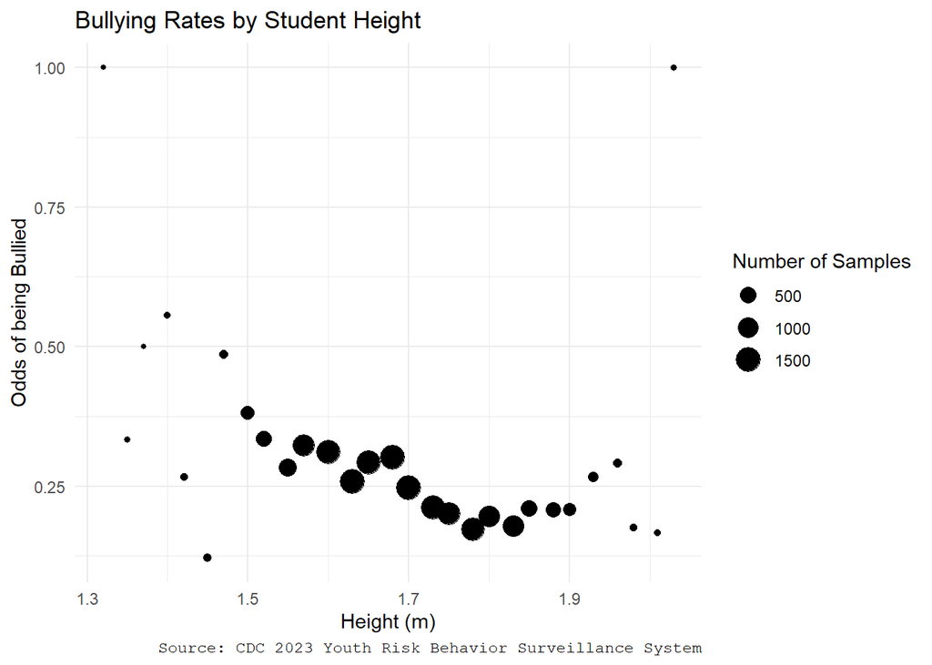

```r
bullied_by_height <- yrbss |>
  group_by(Height) |>
  summarize(Odds = sum(Bullied_at_School=="Yes")/sum(Bullied_at_School=="No"),
            N = n())

ggplot(bullied_by_height, aes(x=Height, y=Odds, size=N) ) +
  geom_point() +
  labs(x="Height (m)",
       y="Odds of being Bullied",
       size="Number of Samples",
       title="Bullying Rates by Student Height",
       caption="Source: CDC 2023 Youth Risk Behavior Surveillance System") +
  theme_minimal() +
  theme(plot.caption = element_text(family="mono"))
```

From this sample of 17,605 high school students, it appears that as a student’s grade level increases, the rate of being a victim of bullying tends to decrease. It also appears that when students are taller, the odds of being a victim of bullying also tends to decrease. The question is, **how can we statistically model this?**

# Generalized Linear Models

For most of this course we have been focused on linear models (hence the function `lm`). One of the key assumptions in linear models is that the underlying random part of the data (that is, the residuals or noise terms) are normally distributed. But not all models are based on normally distributed errors.

**Generalized Linear Models** (GLM) allow for other types of error distributions. GLMs consist of two additional components in addition to a linear model:

- **Family**: the distribution of the response variable.
- A **link** function: it “links” a linear model to the response variable.

Multiple Linear regression is just a special case of GLM with

- Family: Normal Distribution.
- An *identity* Link is used: $f(x)=x$.

Logistic regression is another type of GLM. In this case:

- Family: Binomial Distribution.
- Link: log odds, $f(p)=\log\left(\frac{p}{1-p}\right)$.
  - This is called the *logit* link function.

We will *briefly* overview other GLMs in a future class.

# Logistic Regression

We will revisit the high school bullying dataset, but we begin with a more lighthearted example (unless you happen to be a Wolf Spider…)

## Data Description

The paper “Sexual Cannibalism and Mate Choice Decisions in Wolf Spiders: Influence of Male Size and Secondary Sexual Characteristics” describe a study in which researchers were interested in variables that might be related to a female wolf spider’s decision to kill and consume her partner during courtship or mating. The accompanying data (approximate values read from a graph in the paper) are values of difference in body width (female - male) and whether cannibalism occurs, coded as 0 for no cannibalism and 1 for cannibalism for 52 pairs of courting wolf spiders.

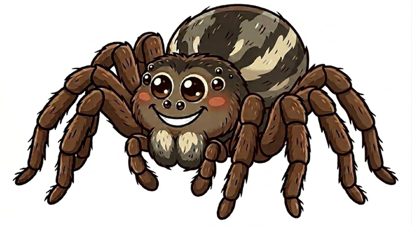

You can get an introduction on the behavior of Wolf spiders by by watching this [short video](https://www.youtube.com/embed/fwUpjWKAsik?rel=0).

**Sources:** Data: (Peck, Olsen, and Devore 2011). Concept (Persons and Uetz 2005). Clipart: (Gemini 2026).

## Some data visualization

There is a binary response (cannibalism or not) and a single predictor (a numeric variable – the difference in size of the two spiders), so we can be creative with visual displays. Below are two examples:

```r
spider <- read_csv("https://tjfisher19.github.io/data/spiderCannibalism.csv",
                   show_col_types = FALSE)
glimpse(spider)
```

```
Rows: 52
Columns: 2
$ SizeDiff    <dbl> -1.0, -1.0, -0.8, -0.8, -0.6, -0.6, -0.4, -0.4, -0.4, -0.4…
$ Cannibalism <dbl> 0, 0, 0, 0, 0, 0, 0, 0, 0, 0, 0, 0, 0, 0, 0, 0, 0, 0, 0, 0…
```

**Coding Note**

The response variable `Cannibalism` is recorded as a 1 or 0. Treating this as a numeric variable has some benefits for certain plots. For other plots, we may want to treat it categorically, so we make a ‘copy’ of that variable that has been turned into a categorical/logical variable.

```r
spider <- spider |>
  mutate(`Male consumed`=as.logical(Cannibalism))
```

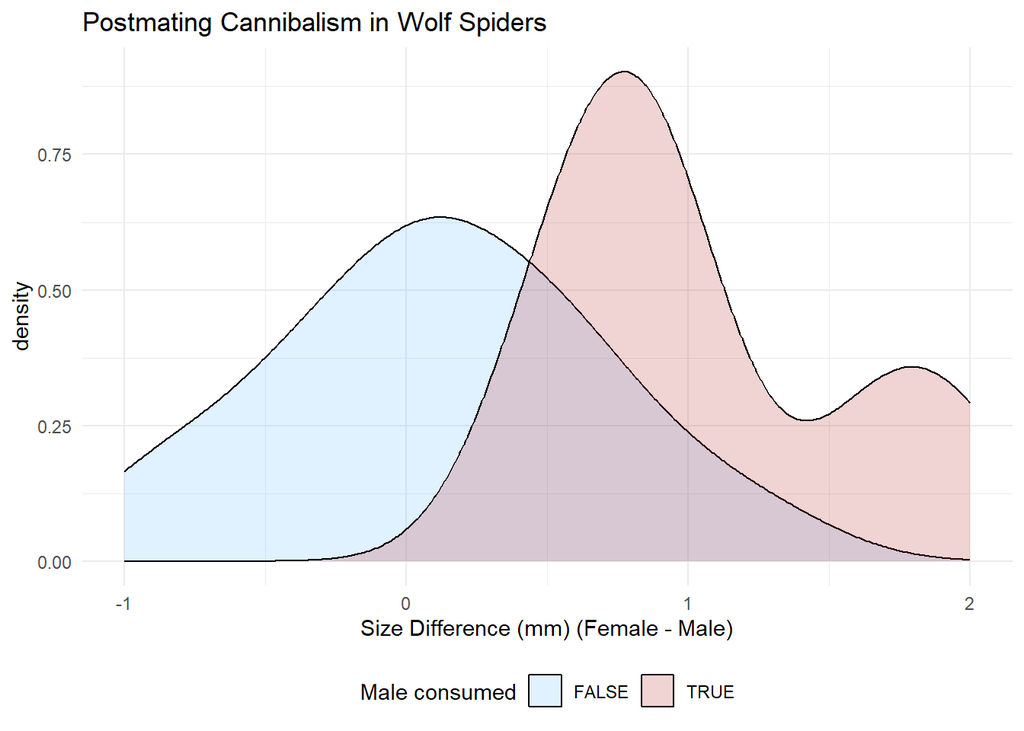

```r
ggplot(spider) +
  geom_density(aes(SizeDiff, fill=`Male consumed`), alpha=0.2) +
  labs(x="Size Difference (mm) (Female - Male)",
       title="Postmating Cannibalism in Wolf Spiders") +
  scale_fill_manual(values=c("steelblue1", "firebrick")) +
  theme_minimal() +
  theme(legend.position="bottom")
```

In the plot we segment the data into two groups (those where cannibalism occurred and those where it did not) and look at the distribution of the size difference variable. This provides some insight into what is happening: the `Male consumed` group generally has larger size differences than the group where the male was not eaten. Keep in mind that in this plot we are looking at the variables backwards (essentially how does $Y$ influence $X$).

Another way to visualize this data is with a scatterplot (with some jittering)

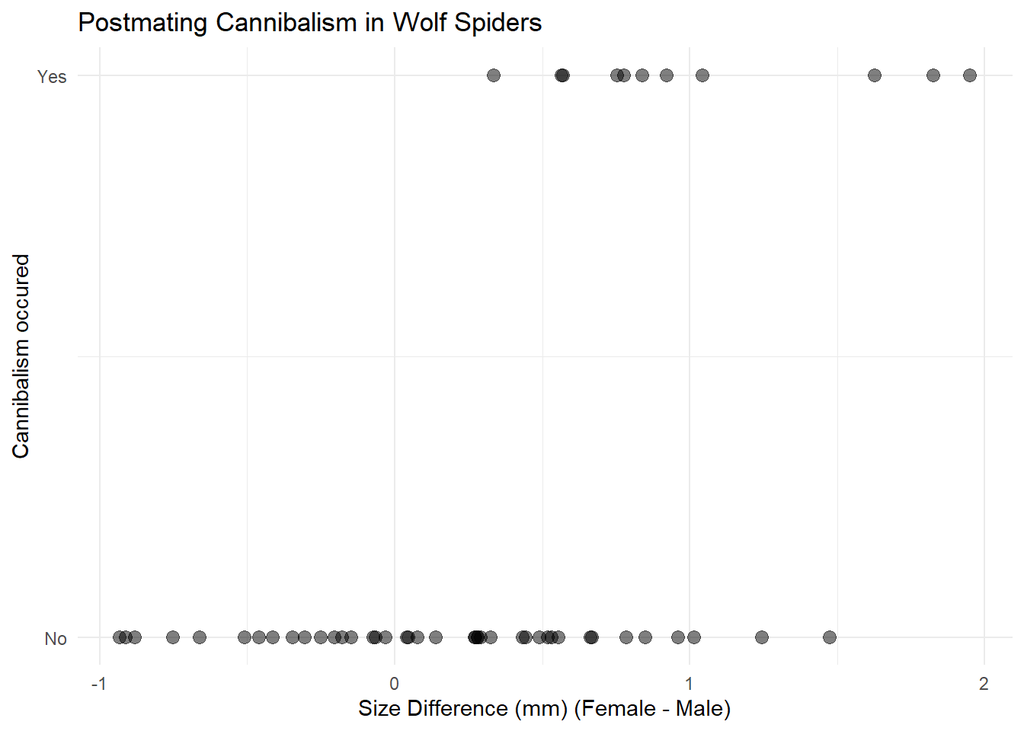

```r
ggplot(spider) +
  geom_jitter(aes(x=SizeDiff, y=Cannibalism),
              height=0, width=0.1, alpha=0.5, size=2.75) +
  labs(x="Size Difference (mm) (Female - Male)",
       y="Cannibalism occured",
       title="Postmating Cannibalism in Wolf Spiders") +
  scale_y_continuous(breaks=c(0,1), labels=c("No", "Yes")) +
  theme_minimal()
```

Visually it looks like larger size differences result in more cases of spider cannibalism. We will model this with **Logistic Regression**.

**Coding Note**

In this second figure we use the numeric version of the response, `Cannibalism`, instead of the categorical version `Male consumed`. Thus, we get 1 and 0 values on the plot. Because it is difficult to parse out the individual observations due to rounding of the size differences, many points are stacked on top of one another so we use of `geom_jitter` instead of `geom_point`. One graphical way to handle this is with *jittering* – wherein we add a little bit of a random “shake” to the data.

Remember jittering just adds some randomness to the plotted observations–it does not change the data. We also use the `alpha` scaling option (where overlapping points will show up darker than stand-alone points) so we can see little clusters of points.

### Using `ggpairs()`

We can use `ggpairs()` to make plots with a binary response but we **need to be judicious** in how the plot is built and interpretation. Below, we plot all three variables (keep in mind we have two versions of the `Cannibalism` variable now).

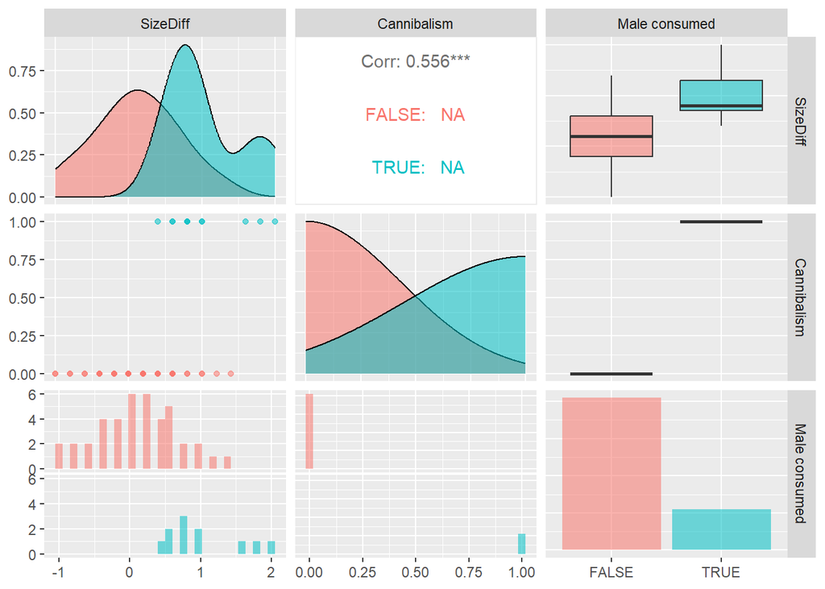

```r
ggpairs(spider, columns = c(1,2,3), mapping=aes(color=`Male consumed`, alpha=0.4) )
```

From the provided pairs plot we can get some of the same information that we saw above – the size difference is bigger when cannibalism occurs.

**Note**

**Several** of the **plots** in the figure are **useless** and provide no insight into the relationship between the predictor variable and response.

## Modeling a Proportion

It is worth reiterating in this example our **response** variable is a **binary** outcome (True/False on whether postmating cannibalism occurred). With this type of data, the parameter of interest is $p$ defined as

$$p = P(\textrm{Postmating Cannibalism Occured}).$$

Since $p$ is a probability (or proportion), we know $0 \leq p \leq 1$, and thus standard linear regression is not appropriate. But consider the *odds* of postmating cannibalism,
$$odds = \frac{p}{1-p},$$
we are now working in the domain $(0, \infty)$. Further, if we take the logarithm of the odds,
$$\log\left(\frac{p}{1-p}\right),$$
we are working in the domain $(-\infty, \infty)$. Think back to your Algebra courses,

- If $0 < odds <1$, then $\log(odds) < 0$.
- If $odds = 1$, then $\log(odds) = 0$.
- When $odds > 1$, then $\log(odds) > 0$.

Linear modeling is more appropriate when working with the log-odds as a ‘response’. Consider modeling the log-odds of postmating cannibalism as a linear function of the size difference between female and male spiders (call this variable $X$).

$$logit(p) = \log\left(\frac{p}{1-p}\right) = \beta_0 + \beta_1 X$$

In terms of $p$ the above model can be written as
$$p = \frac{\exp\left(\beta_0 + \beta_1 X\right)}{1 + \exp\left(\beta_0 + \beta_1 X\right)}$$

This is known as a *logistic equation* and that is why it is called *logistic regression*.

## Fitting the Model in R

To fit a logistic regression in R we use the `glm()` function, which stands for **generalized linear model**. In the derivation above, we are *generalizing* linear modeling to work with some different *family* of data (*i.e.*, something other than Normal data) and we use the *logit* function to *link* the parameter of interest to a linear equation.

When fitting a Generalized Linear Model, we must specify the `family` and `link` functions; the code for the spider cannibalism example is:

```r
spider.fit <- glm(Cannibalism ~ SizeDiff,
                  data=spider,
                  family=binomial(link=logit))
```

**Coding Note**

The code is very similar to the `lm()` and `aov()` code from earlier in the course. The key with `glm()` is we need to specify the distribution of the response (the `family`). We also specify the `link` function, so the code includes the parameter specification: `family=binomial(link=logit)`.

(specification of the link function is *technically not necessary* because `link=logit` is the default for the binomial family)

**Note**

A linear regression model (think `lm()`) is fit using *least squares*. There we find parameter estimates that minimize the error between the data and model structure. The `glm()` function fits models using *Maximum Likelihood Estimation* (typically called MLE). Rather than minimize error, it looks to find the model parameter values that most strongly agree with the data. Details of MLE are covered in STA 462 and STA 463.

**Coding Note**

There is an alternative approach to fitting a logistic regression when the data is provided in a summary form (think the output of the `xtabs()` function). The response variable is provided as a matrix using the function `cbind()` where the first column is the number of successes and the second column is the number of failures; for example `cbind(Successes, Failures)`. See Logistic Lecture 04 for more details and a worked out example.

Much like when fitting a linear regression, we can extract the estimated coefficients from the model.

```r
coefficients(spider.fit)
```

```
(Intercept)    SizeDiff
  -3.089044    3.069281
```

These are the estimated $\hat{\beta_0}$ and $\hat{\beta}_1$ terms from the model that can be expressed in multiple ways:
$$logit(p) = \log\left(\frac{p}{1-p}\right) = \hat{\beta}_0 + \hat{\beta_1} X$$
or
$$\frac{p}{1-p} = \exp\left(\hat{\beta}_0 + \hat{\beta}_1 X\right) = \exp\left(\hat{\beta_0}\right)\times \exp\left(\hat{\beta_1} X\right)$$
or
$$p = \frac{\exp\left(\hat{\beta}_0 + \hat{\beta_1} X\right)}{1 + \exp\left(\hat{\beta}_0 + \hat{\beta_1} X\right)}$$

Below we interpret the fitted model.

## Interpretation of parameters

- The intercept: $\hat{\beta_0}$ = -3.0890444
  - Negative, so when size difference = 0, log-odds of cannibalism will be negative.
  - This means the odds are less than 1.
  - So the probability of postmating cannibalism when there is no size difference is less than 0.5.
  - Specifically, the log odds are $\hat{\beta}_0$ = -3.0890444.
  - Thus, the odds are $\frac{p}{1-p} = \exp(\hat{\beta}_0)$ = 0.0455455.
  - The probability of cannibalism when there is no size difference is 0.0435614.
  - So if the spiders are the same size, there is only about a 4% chance the female will kill and eat the male spider postmating.
- The “slope”: $\hat{\beta_1}$ = 3.0692809
  - Positive, so larger size differences lead to more cannibalism.
  - For every 1 mm increase in size difference, we would expect the log odds to increase by 3.0692809 units.
  - This gets very difficult if you try to interpret in terms of the the probability, since we are modeling the log odds.
  - Think back to algebra: sums of *logs* are multiplication of *exponent* terms, so all increases are relative to the intercept term:
    $$\log\left(\frac{p}{1-p}\right) = \beta_0 + \beta_1 X \Longrightarrow \frac{p}{1-p} = e^{\beta_0 + \beta_1 X} = e^{\beta_0}\times e^{\beta_1 X}$$
    The odds $\frac{p}{1-p}$ will grow at a multiplicative rate of exp(3.0692809) = 21.526418 for each one mm increase in the size difference.

## Further discussions

In this example where there is a single numeric predictor variable, the fitted model can be plotted using the predict function (more detailed provided in Logistic Lecture 03) and techniques we used in the Linear Regression Lecture 02 to plot nonlinear functions:

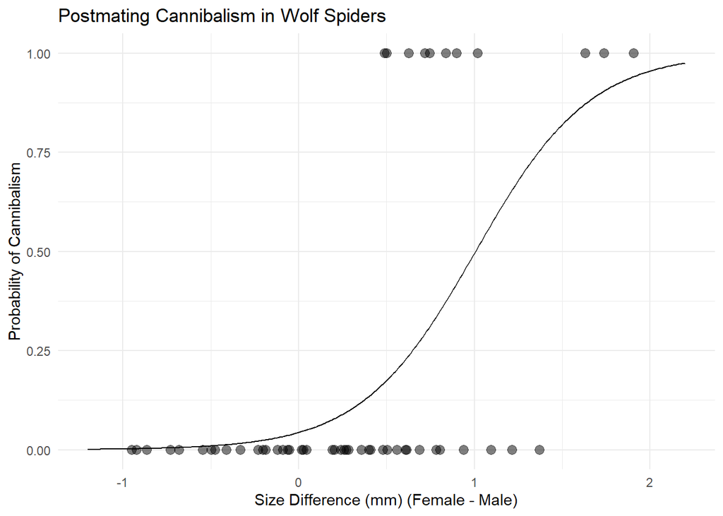

```r
## Data on a fine scale so we can plot curvature
spider.fit.plot.data <- data.frame(SizeDiff=seq(-1.2, 2.2, 0.01))
spider.fit.plot.data <- spider.fit.plot.data %>%
  mutate(Predicted.Prob = predict(spider.fit, newdata=spider.fit.plot.data, type="response"))

## Jittered scatterplot (same as above) with fitted model
ggplot() +
  geom_jitter(data=spider, aes(x=SizeDiff, y=Cannibalism),
              height=0, width=0.1, alpha=0.5, size=2.75) +
  geom_line(data=spider.fit.plot.data, aes(x=SizeDiff, y=Predicted.Prob)) +
    labs(x="Size Difference (mm) (Female - Male)",
       y="Probability of Cannibalism",
       title="Postmating Cannibalism in Wolf Spiders") +
  theme_minimal()
```

If the female is 1 mm larger than the male, we basically have the intercept and slope canceling out ($-3.089 + 3.069(1) \approx 0$), and this results in a log odds near 0, which corresponds to the odds being near 1, and a probability of about 0.5 for cannibalism to occur. This can be seen in the plot.

# YRBSS Bullying Rates Revisited

We will fit a logistic regression model where the indicator variable of whether a student had been bullied in the last year is the response, and two predictor variables are included:

- The grade: with four categories for 9th, 10th, 11th and 12th grades.
- the student’s height (in meters)

**Coding Note**

When performing logistic regression, the `glm()` function in R requires the response variable to be a logical (`FALSE` or `TRUE`), a numeric with two values (`0` or `1`) or a factor variable with two levels. In this example `Bullied_at_School` is a character type, so the `glm()` function would give an error. We create a copy of that response that is a logical variable.

```r
## Create a logical variable
yrbss <- yrbss |>
  mutate(Bullied = Bullied_at_School=="Yes")
```

**Coding Note**

In some previous code working the spider cannibalism example we converted 0 and 1 to `FALSE` and `TRUE` using the `as.logical()` function. Here we perform a logistical comparison. If `Bullied_at_School` takes on the value “Yes”, then the variable `Bullied` will take on the value `TRUE`. If `Bullied_at_Schoool` does not take on the value “Yes”, then `Bullied` will be `FALSE`.

For those with formal programming experience, this is effectively the logic:

```r
if(Bullied_at_School == "Yes")
  then Bullied = TRUE
else
  then Bullied = FALSE
```

With a proper binary response variable, we now use the `glm()` function to fit the logistic model with two predictor variables.

```r
bullying_logit_fit <- glm(Bullied ~ Grade + Height,
                          data=yrbss,
                          family=binomial(link="logit") )
coefficients(bullying_logit_fit)
```

```
    (Intercept) Grade10th grade Grade11th grade Grade12th grade          Height
      1.4628633      -0.2549909      -0.4373265      -0.6201759      -1.5145887
```

To interpret this model, follow the same rules to interpret categorical variables as we did with linear regression; just remember to account for the link function:

- $\hat{\beta_0}$ = 1.4628633
  - The `(Intercept)` here is 9th grade students who have a height of zero meters.
  - The value is positive, so for a 0 meter tall 9th grader, log-odds of being bullied will be positive.
  - This means the odds are greater than 1 and the probability that a zero meter height student being bullied will be greater than 0.5.
  - Specifically, the odds are $\frac{p}{1-p} = \exp(\beta_0)$ = 4.3183065.
  - Thus, the probability of being bullied for a 9th grader with no height is 0.8119702.
  - So for a 9th grader with no height, there is only about an 81% chance the student has been victimized by bullying.
- $\hat{\beta_1}$ = -0.2549909
  - Negative, so a 10th grader will have a decrease in the log odds of being bullied compared to a 9th grader.
  - The log odds a 10th grader is bullied is 1.4628633 + -0.2549909 = 1.2078724.
  - Thus, the odds of a zero meter tall 10th grader being bullied is exp(1.2078724) = 3.3463575
  - and the probability is 0.7699223
- $\hat{\beta_2}$ = -0.4373265
  - Negative, so an 11th grader will have a decrease in the logs odds of being bullied compared to a 9th grader.
- $\hat{\beta_3}$ = -0.6201759
  - Negative, so a 12th grader will have a decrease in the log odds of being bullied compared to a 9th grader.
- $\hat{\beta_4}$ = -1.5145887
  - For every 1 meter increase in height, we would expect the log odds of being bullied to decrease by -1.5145887 units.
  - The odds $\frac{p}{1-p}$ of being bullied will decrease at a multiplicative rate of exp(-1.5145887) = 0.2198986 for each one meter increase in height.
  - Note, this is about a 78% relative decrease per meter.

**Note**

With categorical predictor variables we can more easily work from log-odds to probabilities. In Logistic Regression Lecture 04 we provide an example with only categorical predictor variables.

## Visualizing the Model

Here we have a categorical predictor (with 4 categories) and a numeric predictor to model the log-odds of bullying of a high school student. Given there is a single numeric predictor, we can make a plot of this fitted model.

A visualization of the fitted model:

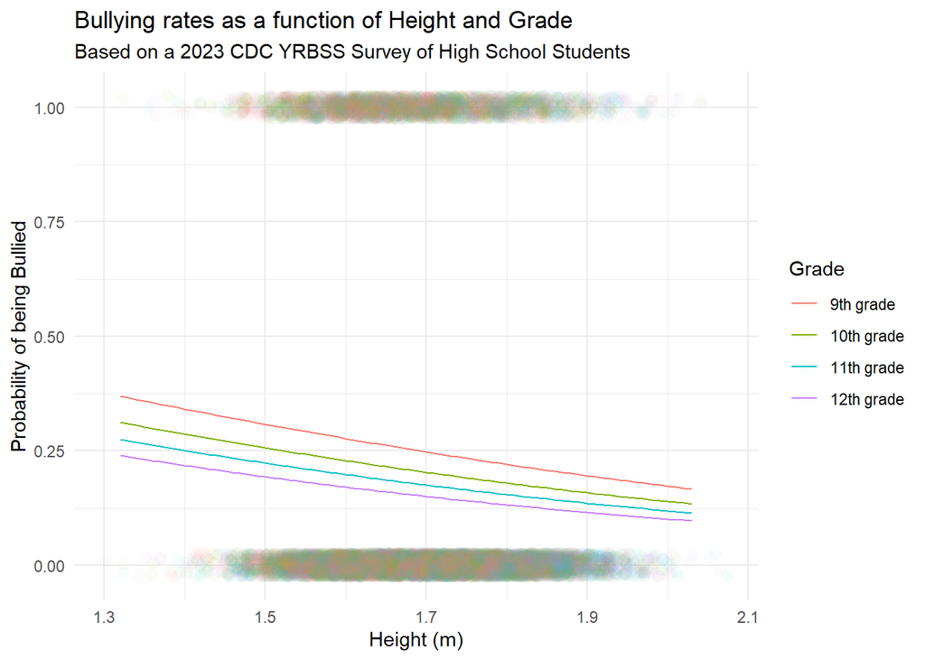

```r
yrbss.fit.plot.data <- data.frame(Height=rep(seq(1.32, 2.03, 0.01), 4),
                                  Grade = rep(c("9th grade", "10th grade", "11th grade", "12th grade"), each=72) ) |>
  mutate(Grade = factor(Grade, levels=c("9th grade", "10th grade", "11th grade", "12th grade") ) )

yrbss.fit.plot.data <- yrbss.fit.plot.data |>
  mutate(Predicted.Prob = predict(bullying_logit_fit, newdata=yrbss.fit.plot.data, type="response"))

ggplot() +
  geom_jitter(data=yrbss, aes(x=Height, y=as.numeric(Bullied), color=Grade ),
              height=0.025, width=0.05, alpha=0.03, size=2.75) +
  geom_line(data=yrbss.fit.plot.data, aes(x=Height, y=Predicted.Prob, color=Grade)) +
    labs(x="Height (m)",
       y="Probability of being Bullied",
       title="Bullying rates as a function of Height and Grade",
       subtitle="Based on a 2023 CDC YRBSS Survey of High School Students") +
  theme_minimal()
```

## Other considerations

In the next lecture, we will see that many of the topics from Linear Regression hold true in Logistic Regression.

- There is an analogous result to the “overall model $F$-test”.
  - Likewise, we can performed analogs to the “reduced model $F$-test”.
- There is an analogous results to the conditional $t$-tests.
- We can calculate an R-squared type measure.
- AIC and BIC values can be calculated from fitted logistic regression models and used in model selection.
- Many of the topics we have learned throughout the semester are still valid with logistic regression: multicollinearity, influential points, etc…

# An aside - Probit Regression

When performing logistic regression in R we specify the family of the distribution (`binomial`) and the associated link function (`logit`, which happens to be the default link function for the `binomial` family). There is another link function that tends to be used in certain applications, particularly in *economics*, known as the *probit* model. Understanding of this model requires a little bit of probability theory.

You should be fairly familiar with the Normal distribution from your intro stat class (you may have even used a standard normal distribution table). The basic idea is to assume the probability of success, $p$, is a normal probability. Let $\Phi$ be the standard normal cumulative distribution function and use it as the basis of a link function.

For the spider cannibalism example, $p$ is the probability cannibalism occurs and we would model
$$p = \Phi\left(\beta_0 + \beta_1 (\text{Size Diff}) \right).$$

So the idea is to take the results of the regression and feed it into a standard normal calculator (or one of those old tables). Thus,

$$\Phi^{-1}(p) = \beta_0 + \beta_1 (\text{Size Diff})$$

This model can be fit in R by specifying `family=binomial(link=probit)` in the `glm` function. The resulting fitted model is **similar to the logistic** regression. However, it turns out that **in most applications interpreting the coefficients of a probit model is more difficult** than that of a logistic model, so we concentrate on logistic models in this class. With that said, you may cross a probit model at some point in your statistical career.

## References

Brener, Nancy D., Jonetta J. Mpofu, Kathleen H. Krause, Sherry Everett Jones, Jemekia E. Thornton, Zachary Myles, William A. Harris, et al. 2024. “Overview and Methods for the Youth Risk Behavior Surveillance System — United States, 2023.” *MMWR Supplements* 73 (4): 1–12. https://doi.org/10.15585/mmwr.su7304a1.

Centers for Disease Control and Prevention. 2024. “2023 Youth Risk Behavior Survey Data.” Atlanta, GA: CDC Website.

Gemini. 2026. “Interaction with Gemini: AI-Generated Clip Art and Marketing Graphics.” Google Gemini (Web Version).

Peck, R., C. Olsen, and J. L. Devore. 2011. *Introduction to Statistics and Data Analysis*. Cengage Learning.

Persons, Matthew H., and George W. Uetz. 2005. “Sexual Cannibalism and Mate Choice Decisions in Wolf Spiders: Influence of Male Size and Secondary Sexual Characters.” *Animal Behaviour* 69 (1): 83–94. https://doi.org/https://doi.org/10.1016/j.anbehav.2003.12.030.